### **Coursera: Reproducible Research: Course Project 1**

Details about this course can be found [here](https://www.coursera.org/learn/reproducible-research). The author of this unremarkable markdown is [Sebastian Kraus](https://www.linkedin.com/in/sebastiankrausjena/) and it’s his first one. Feedback is highly appreciated :).

### **1. Loading and preprocessing the data**

#### **1.1 Load the data**

```r
#url <- "https://d396qusza40orc.cloudfront.net/repdata%2Fdata%2Factivity.zip"
#download.file(url, destfile = "Factivity.zip", method = "auto")
unzip("Factivity.zip", exdir = "data")
dta <- read.csv("data/activity.csv")
```

#### **1.2 Process/transform the data**

```r
library(tidyverse)

dta.n <- mutate(dta, date = as.Date(dta$date))
dta.n <- filter(dta.n, steps != "NA")

head(dta.n)
```

```
##   steps       date interval
## 1     0 2012-10-02        0
## 2     0 2012-10-02        5
## 3     0 2012-10-02       10
## 4     0 2012-10-02       15
## 5     0 2012-10-02       20
## 6     0 2012-10-02       25
```

```r
tail(dta.n)
```

```
##       steps       date interval
## 15259     0 2012-11-29     2330
## 15260     0 2012-11-29     2335
## 15261     0 2012-11-29     2340
## 15262     0 2012-11-29     2345
## 15263     0 2012-11-29     2350
## 15264     0 2012-11-29     2355
```

```r
str(dta.n)
```

```
## 'data.frame':    15264 obs. of  3 variables:
##  $ steps   : int  0 0 0 0 0 0 0 0 0 0 ...
##  $ date    : Date, format: "2012-10-02" "2012-10-02" ...
##  $ interval: int  0 5 10 15 20 25 30 35 40 45 ...
```

### **2. What is mean total number of steps taken per day?**

#### **2.1. Calculate the total number of steps taken per day.**

```r
dta.n.by.day <- group_by(dta.n, date)
st.p.day <- summarise(dta.n.by.day, sum_steps = sum(steps))
st.p.day
```

```
## # A tibble: 53 × 2
##          date sum_steps
##        <date>     <int>
## 1  2012-10-02       126
## 2  2012-10-03     11352
## 3  2012-10-04     12116
## 4  2012-10-05     13294
## 5  2012-10-06     15420
## 6  2012-10-07     11015
## 7  2012-10-09     12811
## 8  2012-10-10      9900
## 9  2012-10-11     10304
## 10 2012-10-12     17382
## # ... with 43 more rows
```

#### **2.2. Make a histogram of the total number of steps taken each day.**

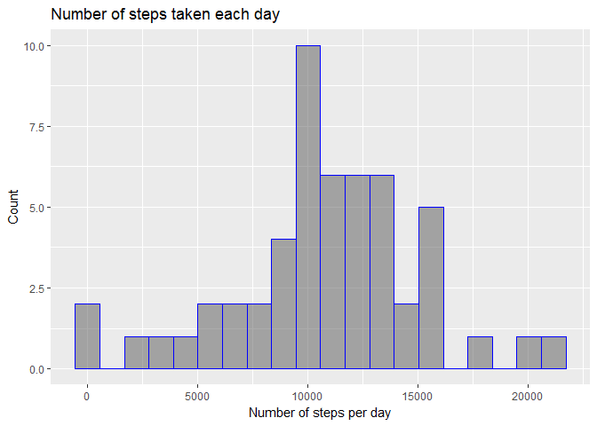

```r
ggplot(data = st.p.day) +
        geom_histogram(mapping = aes(x = sum_steps),bins = 20, col = "blue",
                       alpha = 0.5) +
        labs(title="Number of steps taken each day",
             x="Number of steps per day", y="Count")
```

#### **2.3. Mean and median of the total number of steps per day**

```r
mean(st.p.day$sum_steps)
```

```
## [1] 10766.19
```

```r
median(st.p.day$sum_steps)
```

```
## [1] 10765
```

The total numbers of steps per day have a mean of 10766 and a median of 10765.

### **3. What is the average daily activity pattern?**

#### **3.1. Time series plot :5-minute interval and average number of steps**

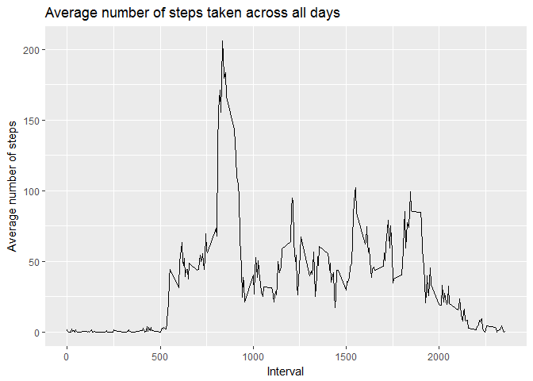

```r
mean.st.p.int <- summarise(group_by(dta.n, interval),
                          mean_steps = mean(steps))

ggplot(data = mean.st.p.int) +
        geom_line(mapping = aes(x = interval, y = mean_steps)) +
        labs(title="Average number of steps taken across all days",
             x="Interval", y="Average number of steps")
```

#### **3.2 Which 5-minute interval contains the maximum number of steps on average?**

```r
mean.st.p.int[which.max(mean.st.p.int$mean_steps),]
```

```
## # A tibble: 1 × 2
##   interval mean_steps
##      <int>      <dbl>
## 1      835   206.1698
```

The 5-minutes interval at 835, on average across all the days in the dataset, contains the maximum number of 206 steps.